# Visualisasi data dengan ggplot

# Pengantar ggplot2

ggplot2 adalah salah satu paket visualisasi data yang paling banyak digunakan dalam bahasa pemrograman R. Paket ini dikembangkan oleh Hadley Wickham dan merupakan bagian dari ekosistem tidyverse. ggplot2 didasarkan pada prinsip Grammar of Graphics, yang memungkinkan pengguna untuk membangun grafik dengan cara yang sistematis dan terstruktur. Dengan ggplot2, Anda dapat membuat berbagai jenis visualisasi, mulai dari grafik sederhana hingga grafik yang kompleks, hanya dengan beberapa baris kode. Hal ini menjadikan ggplot2 sebagai alat yang sangat berguna bagi para analis data dan ilmuwan data.

Salah satu keunggulan utama ggplot2 adalah fleksibilitasnya. Pengguna dapat dengan mudah menyesuaikan elemen visual seperti warna, ukuran, dan bentuk titik, serta menambahkan berbagai komponen seperti label, judul, dan tema. Dengan menggunakan ggplot2, Anda dapat membuat visualisasi yang tidak hanya informatif tetapi juga menarik secara visual. Selain itu, ggplot2 mendukung berbagai jenis data, termasuk data numerik dan kategorikal, sehingga dapat digunakan dalam berbagai konteks analisis.

Komunitas pengguna ggplot2 sangat besar, dan ada banyak sumber daya yang tersedia untuk membantu Anda belajar dan menguasai paket ini. Dokumentasi resmi ggplot2 menyediakan panduan lengkap dan contoh penggunaan, sementara banyak tutorial dan kursus online juga tersedia untuk membantu Anda memahami cara menggunakan ggplot2 secara efektif. Untuk informasi lebih lanjut, Anda dapat mengunjungi [dokumentasi resmi ggplot2](https://ggplot2.tidyverse.org/)dan [tutorial ggplot2 di R for Data Science](https://r4ds.had.co.nz/).

#introduction ggplot2

**ggplot2** menggunakan pendekatan berbasis komponen untuk membangun grafik. Setiap grafik terdiri dari beberapa elemen dasar:

1. **Data**: Sumber data yang akan divisualisasikan.
2. **Aesthetics (aes)**: Menentukan bagaimana data dipetakan ke elemen visual (misalnya, sumbu x dan y, warna, ukuran).
3. **Geometries (geom)**: Jenis grafik yang digunakan (misalnya, titik, garis, histogram).
4. **Statistics**: Menghitung statistik yang diperlukan untuk grafik.
5. **Coordinates**: Menentukan sistem koordinat.

#Dasar-dasar materi ggplot2

Berikut adalah contoh-contoh dasar penggunaan ggplot2:

###menampikan “hello, world” sederhana

```r
print("hello,world")
```

```
## [1] "hello,world"
```

###contoh ringkasan data

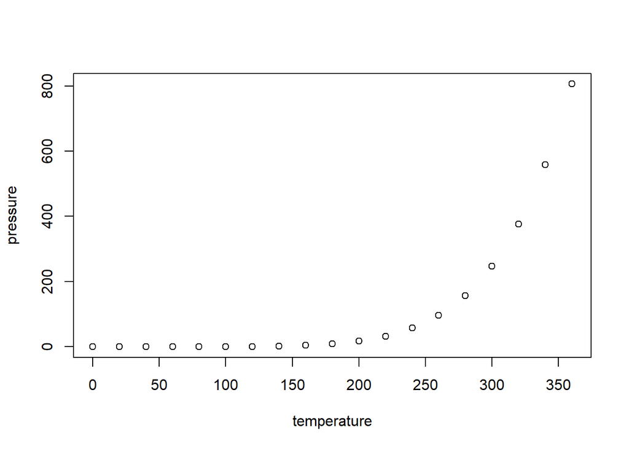

###Membuat Grafik Titik

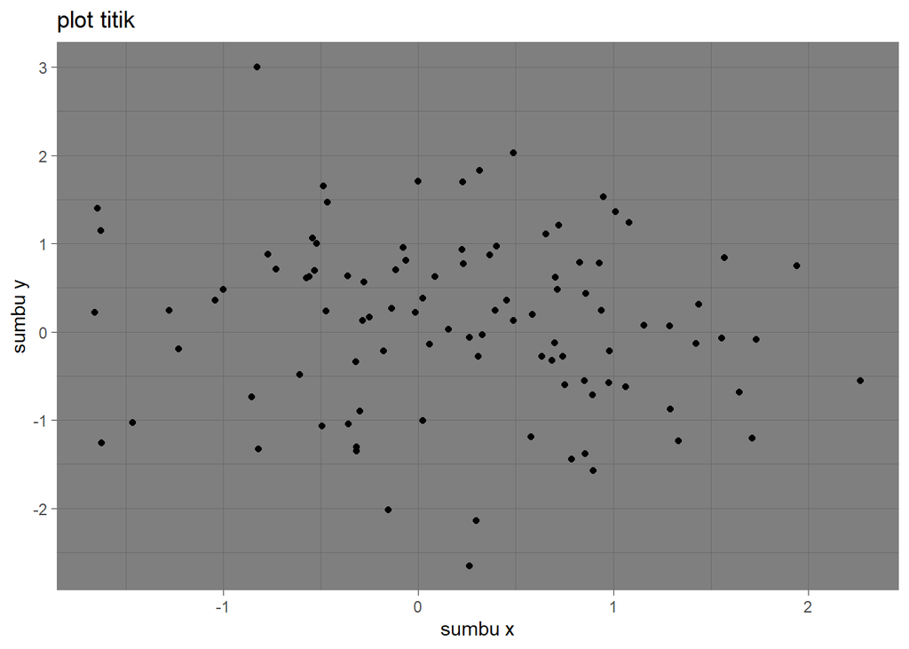

```r
library(ggplot2)
data <- data.frame  (x = rnorm (100), y = rnorm (100))
ggplot(data, aes(x = x, y = y)) +
  geom_point() +
  labs(title = "plot titik", x = "sumbu x", y = "sumbu y") +
  theme_dark()
```

###Faceting dan warna Berdasarkan Grup

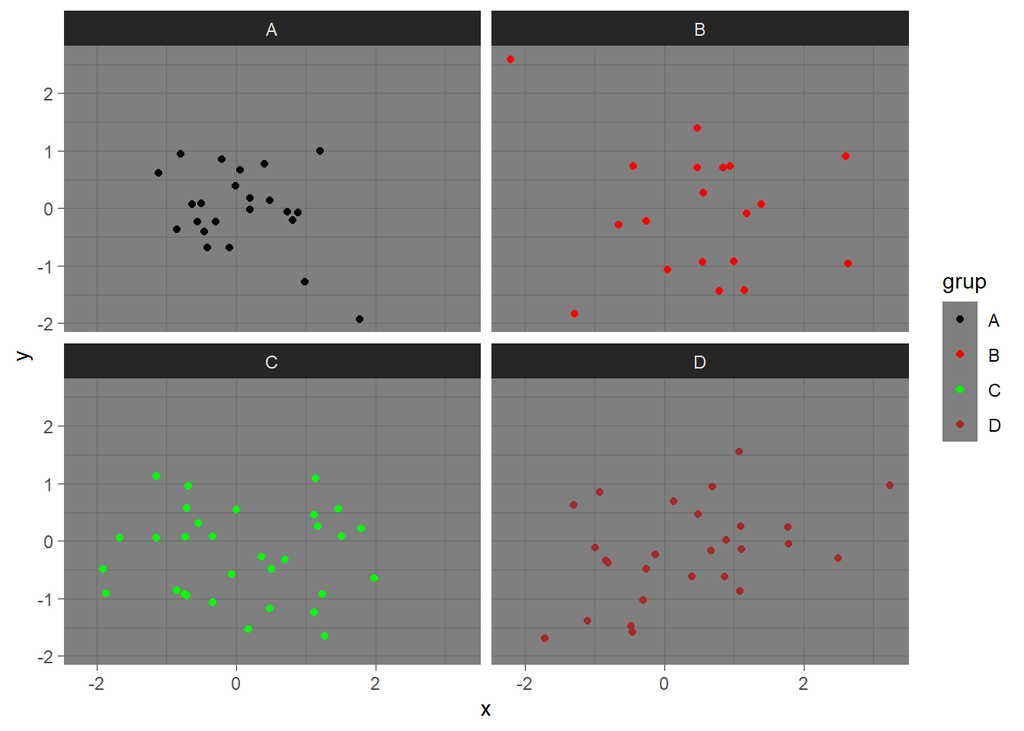

```r
data <- data.frame  (x = rnorm (100), y = rnorm (100), grup = sample(c("A", "B", "C", "D"), 100, replace =TRUE))

ggplot(data, aes (x= x, y= y, color = grup)) +
  geom_point() +
  facet_wrap(~ grup)+
  scale_color_manual(values = c("A" = "black", "B" ="red", "C" = "green", "D" = "brown")) +
  theme_dark()
```

#Read data

Pada bagian ini, kita akan membaca data dari file CSV menggunakan paket `readr`:

```r
library(readr)
lizard <-read_csv("lizards.csv")
View (lizard)
```

###Membuat Grafik dari Data CSV

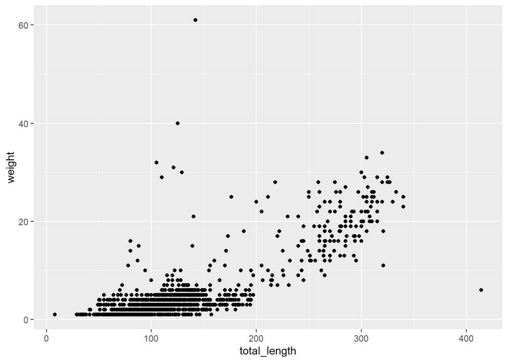

```r
#plot titik dasar
ggplot(lizard, aes (x= total_length, y= weight)) +
  geom_point()
```

```r
  labs(title ="plot titik", x = "total_length", y = "weight")
```

```
## $x
## [1] "total_length"
##
## $y
## [1] "weight"
##
## $title
## [1] "plot titik"
##
## attr(,"class")
## [1] "labels"
```

```r
  theme_dark()
```

[output not shown]

[output cut: 250 more lines]

[output not shown]

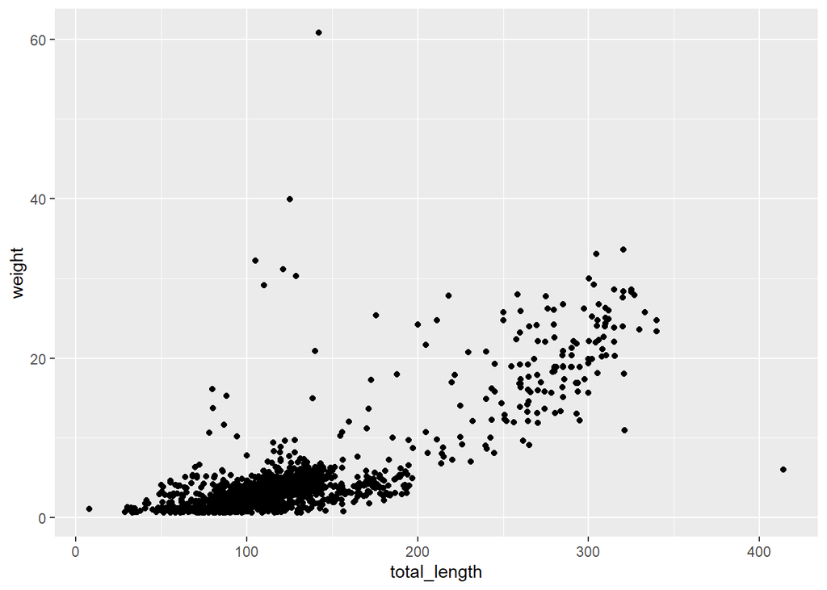

```r
#plot titik dengan jitter
library(ggplot2)
ggplot(lizard, aes (x= total_length, y= weight)) +
  geom_jitter()
```

```r
  labs(title ="plot titik - titik lizard", x = "total_length", y = "common_name")
```

```
## $x
## [1] "total_length"
##
## $y
## [1] "common_name"
##
## $title
## [1] "plot titik - titik lizard"
##
## attr(,"class")
## [1] "labels"
```

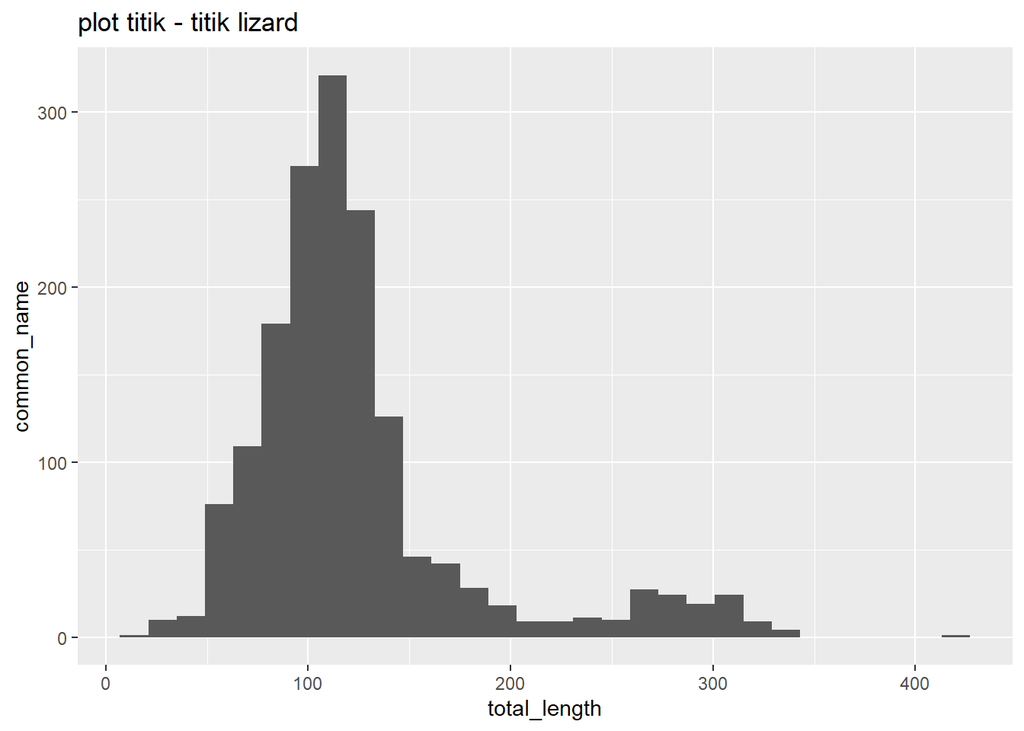

```r
#histogram untuk total length
library (ggplot2)
ggplot(lizard, aes (x= total_length)) +
  geom_histogram() +
  labs(title ="plot titik - titik lizard", x = "total_length", y = "common_name")
```